# Does Your View on Disciplining Children Make You a Potential Murderer?

```r
library(mosaic)
library(tidyverse)
library(pander)
library(DT)
library(ggrepel)
library(plotly)
library(dplyr)
library(ggplot2)
library(maps)
library(tmap)
library(leaflet)
library(htmltools)
library(car)
library(mosaicData)
library(ResourceSelection)
library(reshape2)
library(RColorBrewer)
library(scatterplot3d)
library(readr)
library(prettydoc)
library(knitr)
library(kableExtra)
library(formattable)
library(haven)
```

## Background

The [GSS Data Explorer Page](https://gssdataexplorer.norc.org/variables/vfilter) is a publicly available national source displaying the surveyed results of American Society[^1]. Within this data, I was interested in the `SPANKING` and `POLMURDR` columns. The `SPANKING` column questioned individuals if they favored spanking to discipline their child, the options being : Strongly Agree (1), Agree (2), Disagree (3), Strongly Disagree (4). The `POLMURDR` column questioned individuals if they have ever been questioned as a potential murder suspect, their options being: Yes(1) or No(2).

In this study, we will be using the previous columns provided by GSS Data Explorer to answer the question: *Does your views on disciplining children make you a potential murderer?*

To determine this, we will be using a **Chi-Squared Test** to determine if the preference to discipline your child is *associated or not associated* with being suspected as a potential murder. The data for this study is shown below:

```r
gss2021 <- read_csv("C:/Users/paige/OneDrive/Documents/Fall Semester 2024/MATH 325/Statistics-Notebook-master/Data/gss2021.csv")

childmurdr <- table(gss2021$SPANKING,gss2021$POLMURDR)

rownames(childmurdr) <- c("Strongly Agree", "Agree", "Disagree", "Strongly Disagree") #these replace the 1, 2, and 3

colnames(childmurdr) <- c("Yes", "No") #these replace the 1 and 2

chillM <- gss2021 %>%
  select(SPANKING, POLMURDR)

datatable(chillM, options = list(c(3,10,30)))
```

|  | SPANKING | POLMURDR |
| --- | --- | --- |
| 1 |  | 2 |
| 2 | 3 | 2 |
| 3 | 4 |  |
| 4 | 2 | 2 |
| 5 | 2 |  |
| 6 | 3 |  |
| 7 | 2 | 2 |
| 8 | 4 |  |
| 9 | 3 | 2 |
| 10 |  | 1 |

[output cut: 4022 more lines]

## Hypothesis

Aligned with our question, our null and alternative hypotheses will be stated in the following way:

$$H_0 : \text{A person's views on
spanking as discipline and their status as a murder suspect are
independent.}$$
$$H_a : \text{A
person's views on spanking as discipline and their status as a
murder suspect are associated (not independent.}$$

Additionally, we will be using this level of significance:

$$\alpha = 0.05$$

## Analysis

To discover the answer to our question, we will now look through graphics, tables, and conduct a chi-squared test.

### Graphics

To better visualize our table, we will be using a bar plot. The bar plot at a glance shows that there are significantly more non-murder suspects across all disciplinary views. However, among murder suspects, there was a higher proportion who agreed or strongly agreed with spanking compared to non-suspects with similar views. We will examine these patterns further through chi-squared testing.

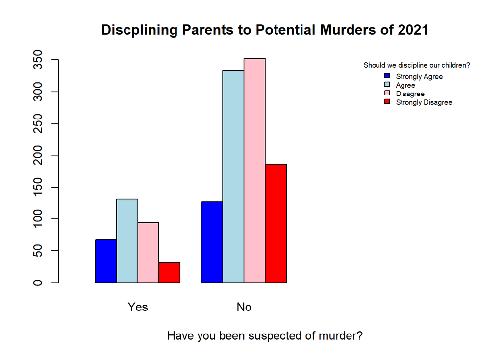

```r
barplot(childmurdr, beside = TRUE, legend.text= TRUE, args.legend = list(title="Should we discipline our children?", x="topright", cex=0.6, bty='n'), col = c("blue", "lightblue", "pink", "red"), xlim= c(0, 18), xlab="Have you been suspected of murder?", main = "Discplining Parents to Potential Murders of 2021")
```

```r
childmurdr %>%
  pander(caption = "2021 Potential Murderers", split.table=Inf)
```

2021 Potential Murderers

|  | Yes | No |
| --- | --- | --- |
| **Strongly Agree** | 67 | 127 |
| **Agree** | 131 | 334 |
| **Disagree** | 94 | 352 |
| **Strongly Disagree** | 32 | 186 |

### $\chi^2$ Test

Below are the results of our $X^2$ test.

```r
chi.murdr <- chisq.test(childmurdr)

pander(chi.murdr)
```

Pearson’s Chi-squared test: `childmurdr`

| Test statistic | df | P value |
| --- | --- | --- |
| 28.16 | 3 | 3.37e-06 * * * |

Based on the p-value of $3.37e^{-6}$, we can **reject** our null hypothesis and conclude that a person’s views on spanking as discipline and their status as a murder suspect are **associated (not independent)**. This can be represented by the following:

$$\text{P-value} = 3.37 e^{-6} <
\alpha$$

### $\chi^2$ Requirements

In order to confirm our findings, we will take a look the requirements by analyzing the **Expected Counts** and the **Residuals**.

There are two things to check when we look at our counts:

1. All expected counts must be **greater than 5**
2. **How far the the residuals** happen when comparing the expected and observed counts

*Click the tabs below to see our results*

#### Expected Counts

As we can see below, **all expected counts are greater than 5**, thus our requirements for this data is met.

```r
pander(chi.murdr$expected)
```

|  | Yes | No |
| --- | --- | --- |
| **Strongly Agree** | 47.51 | 146.5 |
| **Agree** | 113.9 | 351.1 |
| **Disagree** | 109.2 | 336.8 |
| **Strongly Disagree** | 53.39 | 164.6 |

#### Residuals

```r
pander(chi.murdr$residuals)
```

|  | Yes | No |
| --- | --- | --- |
| **Strongly Agree** | 2.828 | -1.61 |
| **Agree** | 1.605 | -0.9138 |
| **Disagree** | -1.457 | 0.8296 |
| **Strongly Disagree** | -2.927 | 1.667 |

## Interpretation

Based on our low p-value of $3.37e^{-6}$, we conclude that **there is an association between a person’s view on spanking and their status as a murder suspect**.

### Sources

- Formatting Inspiration
  - Decade of Movies Chi-Squared Test Example Analysis
[^1]: [About GSS Data Explorer Page](https://gssdataexplorer.norc.org/about)